# Segmentação Celular

```r
# install.packages("randomForest")
# install.packages("ROCR")
# install.packages("e1071")
```

# Objetivo

Esse é um relatório sobre “Segmentação de Células” feito a partir de dados obtidos do Livro “Applied Predictive Analytics”. O objetivo é aprender sobre análise preditiva e ferramentas do R, tais como R Markdown e R Notebook para a elaboração de relatórios como esse.

O objetivo da análise é verificar automaticamente se uma célula foi corretamente particionada ou não.

# Os Dados

## Preparando os dados para o projeto

Inicialmente vamos carregar as bibliotecas necessárias: “scales”, “ggplot2” e “AppliedPredictiveModeling”. Eseg_traina última contém os dados a serem analisados.

```r
# suppressPackageseg_trainartupMessages()
library(scales)
library(ggplot2)
library(caret)
library(randomForest)
library(ROCR)
library(AppliedPredictiveModeling)
data(segmentationOriginal)
confusion = function(conf) {
  percentual = (conf[1, 1] + conf[2, 2]) / sum(conf)
  return (percentual)
};
```

Agora será necessário trabalhar os dados, eliminando algumas colunas que não serão necessárias para a execução da análise.

### Nomenclatura

Uma análise complexa de dados pode requerer a geração de muitos modelos e teseg_traines. Para garantir que não haverá confusão entre os diversos dataframes e modelos, vamos utilizar a seguinte nomenclatura:

1. : o primeiro item do nome é o nome do dataframe;
2. _train: os dados para treinamento;
3. _teseg_train: os dados para teseg_traine;
4. *train*_fit: o modelo utilizado para fazer a previsão
- _train_glm_fit: modelo “generalized linear model”
- _train_cart_fit: modelo de árvore
5. _train_glm_pred: resultado (previsão) da aplicação do modelo (fit)

```r
# separar campos que não serão utilizados durante a análise preditiva
seg_train = subset(segmentationOriginal, segmentationOriginal$Case == "Train")
cell = seg_train$Cell
class = seg_train$Class
# remover as três colunas acima do DF
seg_train = seg_train[, -c(1, 2, 3)]
# remover também as colunas de "seg_trainatus"
status = grep("Status", names(seg_train))
seg_train = seg_train[, -status]
```

Os dados utilizados são dados para a segmentação automática de células, cuja a forma e natureza não precisam ser descritos neseg_traine documento.

Vemos a seguir uma pequena porção dos dados armazenada na variável “segTrain”

```r
head(seg_train)
```

|  | AngleCh1 | AreaCh1 | AvgIntenCh1 | AvgIntenCh2 | AvgIntenCh3 | AvgIntenCh4 | ConvexHullAreaRatioCh1 | ConvexHullPerimRatioCh1 | DiffIntenDensityCh1 | DiffIntenDensityCh3 | DiffIntenDensityCh4 | EntropyIntenCh1 | EntropyIntenCh3 | EntropyIntenCh4 | EqCircDiamCh1 | EqEllipseLWRCh1 | EqEllipseOblateVolCh1 | EqEllipseProlateVolCh1 | EqSphereAreaCh1 | EqSphereVolCh1 | FiberAlign2Ch3 | FiberAlign2Ch4 | FiberLengthCh1 | FiberWidthCh1 | IntenCoocASMCh3 | IntenCoocASMCh4 | IntenCoocContrastCh3 | IntenCoocContrastCh4 | IntenCoocEntropyCh3 | … |
| --- | --- | --- | --- | --- | --- | --- | --- | --- | --- | --- | --- | --- | --- | --- | --- | --- | --- | --- | --- | --- | --- | --- | --- | --- | --- | --- | --- | --- | --- | --- |
| 2 | 133.75204 | 819 | 31.92327 | 205.8785 | 69.91688 | 164.15345 | 1.263158 | 0.7970801 | 31.87500 | 43.12228 | 79.30842 | 6.087592 | 6.642761 | 7.880155 | 32.30558 | 1.558394 | 2232.9055 | 1432.8246 | 3278.726 | 17653.525 | 0.4879354 | 0.3523742 | 64.28230 | 13.167079 | 0.028051061 | 0.012594975 | 8.227953 | 6.984046 | 6.822138 | … |
| 3 | 106.64639 | 431 | 28.03883 | 115.3155 | 63.94175 | 106.69660 | 1.053310 | 0.9354750 | 32.48771 | 35.98577 | 51.35705 | 5.883557 | 6.683000 | 7.144601 | 23.44892 | 1.375386 | 802.1945 | 583.2504 | 1727.410 | 6750.985 | 0.3005220 | 0.5223158 | 21.14115 | 21.141150 | 0.006862315 | 0.006141691 | 14.446074 | 16.700843 | 7.580100 | … |
| 4 | 69.15032 | 298 | 19.45614 | 101.2947 | 28.21754 | 31.02807 | 1.202625 | 0.8658291 | 26.73228 | 22.91732 | 26.39370 | 5.420065 | 5.436732 | 5.778329 | 19.50279 | 3.391220 | 724.7143 | 213.7031 | 1194.932 | 3884.084 | 0.2204239 | 0.7332504 | 43.14112 | 7.404412 | 0.030962071 | 0.011033195 | 7.299457 | 13.390884 | 6.312641 | … |
| 12 | 109.41643 | 256 | 18.82857 | 125.9388 | 13.60000 | 46.80000 | 1.081871 | 0.9204595 | 28.02004 | 14.87082 | 32.69710 | 5.383272 | 4.151183 | 6.194035 | 18.08245 | 1.378748 | 368.3097 | 267.1334 | 1027.222 | 3095.782 | 0.3642360 | 0.4808686 | 22.29743 | 12.057876 | 0.108161298 | 0.009951830 | 6.160585 | 10.590685 | 5.044067 | … |
| 15 | 104.27865 | 258 | 17.57085 | 124.3684 | 22.46154 | 71.20648 | 1.075728 | 0.9313002 | 27.87611 | 16.11947 | 36.18584 | 5.184278 | 5.486225 | 6.624639 | 18.15611 | 1.616053 | 403.6405 | 249.7694 | 1035.608 | 3133.767 | 0.3594184 | 0.2443078 | 26.52856 | 10.174239 | 0.013034881 | 0.008962990 | 9.402056 | 10.301528 | 6.957487 | … |
| 16 | 77.99194 | 358 | 42.28363 | 217.1316 | 42.32164 | 67.54094 | 1.037830 | 0.9612698 | 43.30938 | 43.36563 | 56.04375 | 6.136583 | 5.870027 | 5.995699 | 21.36423 | 1.468210 | 626.8373 | 426.9397 | 1433.918 | 5105.761 | 0.4789638 | 0.4665769 | 25.12696 | 14.610886 | 0.024982639 | 0.044225099 | 11.841077 | 8.084776 | 6.794864 | … |

e sua estrutura

```r
str(seg_train)
```

```
'data.frame':   1009 obs. of  58 variables:
 $ AngleCh1               : num  133.8 106.6 69.2 109.4 104.3 ...
 $ AreaCh1                : int  819 431 298 256 258 358 158 315 246 223 ...
 $ AvgIntenCh1            : num  31.9 28 19.5 18.8 17.6 ...
 $ AvgIntenCh2            : num  206 115 101 126 124 ...
 $ AvgIntenCh3            : num  69.9 63.9 28.2 13.6 22.5 ...
 $ AvgIntenCh4            : num  164.2 106.7 31 46.8 71.2 ...
 $ ConvexHullAreaRatioCh1 : num  1.26 1.05 1.2 1.08 1.08 ...
 $ ConvexHullPerimRatioCh1: num  0.797 0.935 0.866 0.92 0.931 ...
 $ DiffIntenDensityCh1    : num  31.9 32.5 26.7 28 27.9 ...
 $ DiffIntenDensityCh3    : num  43.1 36 22.9 14.9 16.1 ...
 $ DiffIntenDensityCh4    : num  79.3 51.4 26.4 32.7 36.2 ...
 $ EntropyIntenCh1        : num  6.09 5.88 5.42 5.38 5.18 ...
 $ EntropyIntenCh3        : num  6.64 6.68 5.44 4.15 5.49 ...
 $ EntropyIntenCh4        : num  7.88 7.14 5.78 6.19 6.62 ...
```

[output cut: 44 more lines]

```r
summary(class)
```

```
 PS  WS
636 373
```

# Primeiro Modelo

Vamos inicialmente criar um primeiro modelo para prever se uma célula foi bem segmentada (WS) ou mal segmentada (PS).

Usaremos para tal um modelo baseado em “Logiseg_trainic Regression”, usando o método “glm”.

Mas antes de executarmos o modelo é necessário criar um DataFrame com os as variáveis independentes e a variável dependente:

```r
seg_train1 = seg_train
seg_train1$Class = class
```

Vamos verificar a estrutura de seg_train1:

```r
str(seg_train1)
```

```
'data.frame':   1009 obs. of  59 variables:
 $ AngleCh1               : num  133.8 106.6 69.2 109.4 104.3 ...
 $ AreaCh1                : int  819 431 298 256 258 358 158 315 246 223 ...
 $ AvgIntenCh1            : num  31.9 28 19.5 18.8 17.6 ...
 $ AvgIntenCh2            : num  206 115 101 126 124 ...
 $ AvgIntenCh3            : num  69.9 63.9 28.2 13.6 22.5 ...
 $ AvgIntenCh4            : num  164.2 106.7 31 46.8 71.2 ...
 $ ConvexHullAreaRatioCh1 : num  1.26 1.05 1.2 1.08 1.08 ...
 $ ConvexHullPerimRatioCh1: num  0.797 0.935 0.866 0.92 0.931 ...
 $ DiffIntenDensityCh1    : num  31.9 32.5 26.7 28 27.9 ...
 $ DiffIntenDensityCh3    : num  43.1 36 22.9 14.9 16.1 ...
 $ DiffIntenDensityCh4    : num  79.3 51.4 26.4 32.7 36.2 ...
 $ EntropyIntenCh1        : num  6.09 5.88 5.42 5.38 5.18 ...
 $ EntropyIntenCh3        : num  6.64 6.68 5.44 4.15 5.49 ...
 $ EntropyIntenCh4        : num  7.88 7.14 5.78 6.19 6.62 ...
```

[output cut: 45 more lines]

```r
seg_train1_glm_fit = glm(Class ~ ., data=seg_train1, family=binomial())
```

Vemos que o modelo1 não é muito bom pela baixa significância das variáveis independentes na previsão da variável dependente: a grande maioria das variáveis não tem ‘.’, ‘*’, ’**’, ’***’

```r
summary(seg_train1_glm_fit)
```

```
Call:
glm(formula = Class ~ ., family = binomial(), data = seg_train1)

Deviance Residuals:
    Min       1Q   Median       3Q      Max
-2.9177  -0.5479  -0.1826   0.5992   3.1945

Coefficients: (1 not defined because of singularities)
                          Estimate Std. Error z value Pr(>|z|)
(Intercept)             -1.400e+01  1.004e+01  -1.395  0.16308
AngleCh1                -7.633e-05  1.961e-03  -0.039  0.96895
AreaCh1                 -2.953e-01  3.319e-01  -0.890  0.37358
AvgIntenCh1              1.422e-03  4.041e-03   0.352  0.72491
AvgIntenCh2              5.250e-03  2.292e-03   2.291  0.02197 *
AvgIntenCh3              1.114e-02  5.836e-03   1.909  0.05627 .
AvgIntenCh4             -4.374e-03  3.375e-03  -1.296  0.19499
ConvexHullAreaRatioCh1   2.631e-02  2.328e+00   0.011  0.99098
ConvexHullPerimRatioCh1  5.096e-01  6.128e+00   0.083  0.93372
DiffIntenDensityCh1      2.761e-03  1.179e-02   0.234  0.81495
DiffIntenDensityCh3     -1.680e-02  8.384e-03  -2.003  0.04514 *
DiffIntenDensityCh4      1.185e-02  6.149e-03   1.927  0.05394 .
EntropyIntenCh1          3.906e-01  2.855e-01   1.368  0.17128
EntropyIntenCh3          2.684e-01  3.976e-01   0.675  0.49969
EntropyIntenCh4         -4.048e-02  3.932e-01  -0.103  0.91801
EqCircDiamCh1           -2.436e-04  5.255e-01   0.000  0.99963
EqEllipseLWRCh1          7.977e-02  6.669e-01   0.120  0.90479
EqEllipseOblateVolCh1   -4.845e-05  1.431e-03  -0.034  0.97299
EqEllipseProlateVolCh1   3.441e-03  4.578e-03   0.752  0.45223
EqSphereAreaCh1          7.365e-02  8.344e-02   0.883  0.37739
EqSphereVolCh1          -4.370e-04  6.815e-04  -0.641  0.52140
FiberAlign2Ch3          -2.489e-02  4.252e-01  -0.059  0.95332
FiberAlign2Ch4          -6.311e-01  4.743e-01  -1.331  0.18331
FiberLengthCh1           1.783e-01  9.825e-02   1.815  0.06949 .
FiberWidthCh1            5.093e-01  1.660e-01   3.069  0.00215 **
IntenCoocASMCh3          2.569e+00  3.064e+00   0.838  0.40186
IntenCoocASMCh4          4.929e-01  3.700e+00   0.133  0.89402
IntenCoocContrastCh3    -2.327e-02  4.265e-02  -0.546  0.58530
IntenCoocContrastCh4    -6.357e-02  5.450e-02  -1.166  0.24346
IntenCoocEntropyCh3      3.208e-01  9.748e-01   0.329  0.74212
IntenCoocEntropyCh4      5.419e-01  1.031e+00   0.526  0.59911
```

[output cut: 23 more lines]

```
VarIntenCh3              4.196e-03  3.673e-03   1.142  0.25332
VarIntenCh4             -8.372e-03  3.928e-03  -2.131  0.03307 *
WidthCh1                -1.608e-01  1.402e-01  -1.147  0.25159
XCentroid                3.594e-04  6.977e-04   0.515  0.60648
YCentroid                5.988e-04  9.940e-04   0.602  0.54692
---
Signif. codes:  0 ‘***’ 0.001 ‘**’ 0.01 ‘*’ 0.05 ‘.’ 0.1 ‘ ’ 1

(Dispersion parameter for binomial family taken to be 1)

    Null deviance: 1329.42  on 1008  degrees of freedom
Residual deviance:  755.62  on  951  degrees of freedom
AIC: 871.62

Number of Fisher Scoring iterations: 6
```

# Trabalhando os Dados

```r
seg_train2 = seg_train
# definir como pré-processar os dados
pre_processo = preProcess(seg_train2, method=c("BoxCox", "center", "scale", "pca"))
# aplicar o pre_processo aos dados do próximo modelo
seg_train2 = predict(pre_processo, seg_train2)
```

Vamos olhar agora a eseg_trainrutura de seg_train2Trans:

```r
str(seg_train2)
```

```
'data.frame':   1009 obs. of  19 variables:
 $ PC1 : num  1.568 -0.666 3.75 0.377 1.064 ...
 $ PC2 : num  6.291 2.046 -0.392 -2.19 -1.465 ...
 $ PC3 : num  -0.333 -1.442 -0.669 1.438 -0.99 ...
 $ PC4 : num  -3.06 -4.7 -4.02 -5.33 -5.63 ...
 $ PC5 : num  -1.342 -1.742 1.793 -0.407 -0.865 ...
 $ PC6 : num  0.393 0.431 -0.854 1.109 0.107 ...
 $ PC7 : num  -1.3178 1.2845 -0.0709 0.7023 0.4964 ...
 $ PC8 : num  -1.897 -3.083 -0.6 -0.967 -0.657 ...
 $ PC9 : num  0.711 1.997 0.987 0.497 0.492 ...
 $ PC10: num  0.1619 0.5867 -0.4723 -0.1093 -0.0165 ...
 $ PC11: num  1.4406 0.8008 1.2223 1.5996 0.0115 ...
 $ PC12: num  -0.665 1.448 1.128 -0.667 -0.715 ...
 $ PC13: num  -0.5034 0.4488 -1.3748 -1.2675 -0.0683 ...
 $ PC14: num  -0.525 -0.43 -1.488 -0.201 -0.293 ...
 $ PC15: num  0.20954 -0.61043 -0.71269 0.13589 0.00303 ...
 $ PC16: num  0.00141 -1.05835 -0.35975 -1.1256 -0.04698 ...
 $ PC17: num  0.7837 -0.79106 -0.00291 -0.02538 -0.67804 ...
 $ PC18: num  -0.5552 0.0657 1.3574 -0.6319 -0.5846 ...
 $ PC19: num  0.6813 0.1416 0.1019 -0.9681 0.0508 ...
```

# Segundo Modelo

Vamos agora construir nosso DF com as variáveis independentes e a variável dependente:

```r
seg_train2$Class = class
str(seg_train2)
```

```
'data.frame':   1009 obs. of  20 variables:
 $ PC1  : num  1.568 -0.666 3.75 0.377 1.064 ...
 $ PC2  : num  6.291 2.046 -0.392 -2.19 -1.465 ...
 $ PC3  : num  -0.333 -1.442 -0.669 1.438 -0.99 ...
 $ PC4  : num  -3.06 -4.7 -4.02 -5.33 -5.63 ...
 $ PC5  : num  -1.342 -1.742 1.793 -0.407 -0.865 ...
 $ PC6  : num  0.393 0.431 -0.854 1.109 0.107 ...
 $ PC7  : num  -1.3178 1.2845 -0.0709 0.7023 0.4964 ...
 $ PC8  : num  -1.897 -3.083 -0.6 -0.967 -0.657 ...
 $ PC9  : num  0.711 1.997 0.987 0.497 0.492 ...
 $ PC10 : num  0.1619 0.5867 -0.4723 -0.1093 -0.0165 ...
 $ PC11 : num  1.4406 0.8008 1.2223 1.5996 0.0115 ...
 $ PC12 : num  -0.665 1.448 1.128 -0.667 -0.715 ...
 $ PC13 : num  -0.5034 0.4488 -1.3748 -1.2675 -0.0683 ...
 $ PC14 : num  -0.525 -0.43 -1.488 -0.201 -0.293 ...
 $ PC15 : num  0.20954 -0.61043 -0.71269 0.13589 0.00303 ...
 $ PC16 : num  0.00141 -1.05835 -0.35975 -1.1256 -0.04698 ...
 $ PC17 : num  0.7837 -0.79106 -0.00291 -0.02538 -0.67804 ...
 $ PC18 : num  -0.5552 0.0657 1.3574 -0.6319 -0.5846 ...
 $ PC19 : num  0.6813 0.1416 0.1019 -0.9681 0.0508 ...
 $ Class: Factor w/ 2 levels "PS","WS": 1 2 1 2 1 1 1 2 2 2 ...
```

```r
seg_train2_glm_fit = glm(Class ~ ., data = seg_train2, family=binomial())
summary(seg_train2_glm_fit)
```

```
Call:
glm(formula = Class ~ ., family = binomial(), data = seg_train2)

Deviance Residuals:
    Min       1Q   Median       3Q      Max
-2.5019  -0.6242  -0.2722   0.7114   2.9244

Coefficients:
            Estimate Std. Error z value Pr(>|z|)
(Intercept) -0.93746    0.09746  -9.619  < 2e-16 ***
PC1         -0.40327    0.03030 -13.310  < 2e-16 ***
PC2          0.16446    0.02797   5.880 4.11e-09 ***
PC3          0.37609    0.03482  10.800  < 2e-16 ***
PC4         -0.04223    0.04374  -0.965 0.334331
PC5         -0.12694    0.05566  -2.281 0.022569 *
PC6         -0.19653    0.06026  -3.262 0.001108 **
PC7          0.23327    0.06263   3.725 0.000196 ***
PC8         -0.07933    0.06069  -1.307 0.191189
PC9          0.09848    0.07597   1.296 0.194889
PC10        -0.02239    0.07300  -0.307 0.759066
PC11         0.01290    0.09166   0.141 0.888107
PC12         0.15369    0.08368   1.837 0.066252 .
PC13        -0.01373    0.08463  -0.162 0.871157
PC14         0.08635    0.09591   0.900 0.367980
PC15        -0.00205    0.09596  -0.021 0.982959
PC16         0.01940    0.09920   0.196 0.844919
PC17         0.03587    0.10517   0.341 0.733026
PC18         0.14244    0.10848   1.313 0.189159
PC19        -0.21108    0.10816  -1.951 0.050998 .
---
Signif. codes:  0 ‘***’ 0.001 ‘**’ 0.01 ‘*’ 0.05 ‘.’ 0.1 ‘ ’ 1

(Dispersion parameter for binomial family taken to be 1)

    Null deviance: 1329.42  on 1008  degrees of freedom
Residual deviance:  867.51  on  989  degrees of freedom
AIC: 907.51

Number of Fisher Scoring iterations: 5
```

Observamos agora que o modelo é muito mais robuseg_traino que o anterior, com 6 variáveis independentes com forte impacto no modelo, além de duas com certa relevância. Vamos, a partir de agora remover componentes, um de cada vez, com pouco impacto no modelo para ver se conseguimos melhorá-lo.

Vamos remover PC15 do modelo, visto que é aquele que tem maior Pr.

# Terceiro Modelo

```r
seg_train3 = seg_train2[, -15]
seg_train3_glm_fit = glm(Class ~ ., data = seg_train3, family=binomial())
summary(seg_train3_glm_fit)
```

```
Call:
glm(formula = Class ~ ., family = binomial(), data = seg_train3)

Deviance Residuals:
    Min       1Q   Median       3Q      Max
-2.5020  -0.6236  -0.2720   0.7112   2.9243

Coefficients:
            Estimate Std. Error z value Pr(>|z|)
(Intercept) -0.93739    0.09739  -9.625  < 2e-16 ***
PC1         -0.40329    0.03029 -13.314  < 2e-16 ***
PC2          0.16444    0.02795   5.882 4.04e-09 ***
PC3          0.37607    0.03480  10.805  < 2e-16 ***
PC4         -0.04229    0.04365  -0.969 0.332656
PC5         -0.12693    0.05567  -2.280 0.022613 *
PC6         -0.19660    0.06018  -3.267 0.001087 **
PC7          0.23330    0.06262   3.726 0.000195 ***
PC8         -0.07936    0.06067  -1.308 0.190833
PC9          0.09847    0.07600   1.296 0.195082
PC10        -0.02247    0.07291  -0.308 0.757999
PC11         0.01276    0.09145   0.139 0.889071
PC12         0.15370    0.08368   1.837 0.066233 .
PC13        -0.01380    0.08457  -0.163 0.870367
PC14         0.08644    0.09582   0.902 0.367017
PC16         0.01926    0.09903   0.195 0.845767
PC17         0.03592    0.10517   0.342 0.732717
PC18         0.14253    0.10842   1.315 0.188639
PC19        -0.21102    0.10813  -1.951 0.051004 .
---
Signif. codes:  0 ‘***’ 0.001 ‘**’ 0.01 ‘*’ 0.05 ‘.’ 0.1 ‘ ’ 1

(Dispersion parameter for binomial family taken to be 1)

    Null deviance: 1329.42  on 1008  degrees of freedom
Residual deviance:  867.51  on  990  degrees of freedom
AIC: 905.51

Number of Fisher Scoring iterations: 5
```

# Quarto Modelo

```r
seg_train4 = seg_train3[, -11]
seg_train4_glm_fit = glm(Class ~ ., data = seg_train4, family=binomial())
summary(seg_train4_glm_fit)
```

```
Call:
glm(formula = Class ~ ., family = binomial(), data = seg_train4)

Deviance Residuals:
    Min       1Q   Median       3Q      Max
-2.5015  -0.6231  -0.2728   0.7103   2.9249

Coefficients:
            Estimate Std. Error z value Pr(>|z|)
(Intercept) -0.93787    0.09734  -9.635  < 2e-16 ***
PC1         -0.40380    0.03009 -13.419  < 2e-16 ***
PC2          0.16478    0.02786   5.914 3.34e-09 ***
PC3          0.37597    0.03480  10.804  < 2e-16 ***
PC4         -0.04302    0.04336  -0.992 0.321192
PC5         -0.12601    0.05530  -2.279 0.022687 *
PC6         -0.19666    0.06014  -3.270 0.001075 **
PC7          0.23262    0.06243   3.726 0.000195 ***
PC8         -0.07931    0.06066  -1.308 0.191023
PC9          0.09938    0.07569   1.313 0.189170
PC10        -0.02369    0.07244  -0.327 0.743642
PC12         0.15349    0.08367   1.834 0.066598 .
PC13        -0.01321    0.08444  -0.156 0.875652
PC14         0.08852    0.09474   0.934 0.350147
PC16         0.01757    0.09829   0.179 0.858161
PC17         0.03788    0.10427   0.363 0.716367
PC18         0.14529    0.10670   1.362 0.173330
PC19        -0.21136    0.10811  -1.955 0.050585 .
---
Signif. codes:  0 ‘***’ 0.001 ‘**’ 0.01 ‘*’ 0.05 ‘.’ 0.1 ‘ ’ 1

(Dispersion parameter for binomial family taken to be 1)

    Null deviance: 1329.42  on 1008  degrees of freedom
Residual deviance:  867.53  on  991  degrees of freedom
AIC: 903.53

Number of Fisher Scoring iterations: 5
```

# Quinto Modelo

```r
seg_train5 = seg_train4[, -12]
seg_train5_glm_fit = glm(Class ~ ., data = seg_train5, family=binomial())
summary(seg_train5_glm_fit)
```

```
Call:
glm(formula = Class ~ ., family = binomial(), data = seg_train5)

Deviance Residuals:
    Min       1Q   Median       3Q      Max
-2.4946  -0.6246  -0.2736   0.7128   2.9297

Coefficients:
            Estimate Std. Error z value Pr(>|z|)
(Intercept) -0.93679    0.09704  -9.653  < 2e-16 ***
PC1         -0.40358    0.03005 -13.431  < 2e-16 ***
PC2          0.16490    0.02786   5.919 3.23e-09 ***
PC3          0.37566    0.03473  10.817  < 2e-16 ***
PC4         -0.04275    0.04333  -0.987 0.323842
PC5         -0.12628    0.05525  -2.286 0.022281 *
PC6         -0.19670    0.06008  -3.274 0.001061 **
PC7          0.23223    0.06240   3.721 0.000198 ***
PC8         -0.07960    0.06064  -1.313 0.189318
PC9          0.09960    0.07562   1.317 0.187799
PC10        -0.02435    0.07232  -0.337 0.736399
PC12         0.15386    0.08366   1.839 0.065890 .
PC14         0.08946    0.09454   0.946 0.344008
PC16         0.01746    0.09818   0.178 0.858829
PC17         0.03808    0.10420   0.365 0.714760
PC18         0.14596    0.10663   1.369 0.171030
PC19        -0.21193    0.10807  -1.961 0.049878 *
---
Signif. codes:  0 ‘***’ 0.001 ‘**’ 0.01 ‘*’ 0.05 ‘.’ 0.1 ‘ ’ 1

(Dispersion parameter for binomial family taken to be 1)

    Null deviance: 1329.42  on 1008  degrees of freedom
Residual deviance:  867.55  on  992  degrees of freedom
AIC: 901.55

Number of Fisher Scoring iterations: 5
```

# Sexto Modelo

```r
seg_train6 = seg_train5[, -13]
seg_train6_glm_fit = glm(Class ~ ., data = seg_train6, family=binomial())
summary(seg_train6_glm_fit)
```

```
Call:
glm(formula = Class ~ ., family = binomial(), data = seg_train6)

Deviance Residuals:
    Min       1Q   Median       3Q      Max
-2.4810  -0.6282  -0.2731   0.7129   2.9264

Coefficients:
            Estimate Std. Error z value Pr(>|z|)
(Intercept) -0.93720    0.09699  -9.663  < 2e-16 ***
PC1         -0.40386    0.03001 -13.457  < 2e-16 ***
PC2          0.16515    0.02783   5.935 2.94e-09 ***
PC3          0.37538    0.03467  10.826  < 2e-16 ***
PC4         -0.04302    0.04331  -0.993 0.320561
PC5         -0.12608    0.05539  -2.276 0.022831 *
PC6         -0.19762    0.06007  -3.290 0.001002 **
PC7          0.23178    0.06243   3.713 0.000205 ***
PC8         -0.07970    0.06065  -1.314 0.188855
PC9          0.09948    0.07585   1.311 0.189691
PC10        -0.02536    0.07217  -0.351 0.725303
PC12         0.15376    0.08364   1.838 0.066017 .
PC14         0.09148    0.09396   0.974 0.330247
PC17         0.03928    0.10415   0.377 0.706088
PC18         0.14721    0.10643   1.383 0.166629
PC19        -0.21343    0.10783  -1.979 0.047776 *
---
Signif. codes:  0 ‘***’ 0.001 ‘**’ 0.01 ‘*’ 0.05 ‘.’ 0.1 ‘ ’ 1

(Dispersion parameter for binomial family taken to be 1)

    Null deviance: 1329.42  on 1008  degrees of freedom
Residual deviance:  867.59  on  993  degrees of freedom
AIC: 899.59

Number of Fisher Scoring iterations: 5
```

# Sétimo Modelo

```r
seg_train7 = seg_train6[, -10]
seg_train7_glm_fit = glm(Class ~ ., data = seg_train7, family=binomial())
summary(seg_train7_glm_fit)
```

```
Call:
glm(formula = Class ~ ., family = binomial(), data = seg_train7)

Deviance Residuals:
    Min       1Q   Median       3Q      Max
-2.4870  -0.6319  -0.2737   0.7116   2.9222

Coefficients:
            Estimate Std. Error z value Pr(>|z|)
(Intercept) -0.93462    0.09661  -9.674  < 2e-16 ***
PC1         -0.40287    0.02984 -13.502  < 2e-16 ***
PC2          0.16494    0.02782   5.928 3.07e-09 ***
PC3          0.37493    0.03465  10.820  < 2e-16 ***
PC4         -0.04156    0.04308  -0.965 0.334690
PC5         -0.12574    0.05529  -2.274 0.022963 *
PC6         -0.19618    0.05981  -3.280 0.001037 **
PC7          0.23301    0.06222   3.745 0.000181 ***
PC8         -0.07951    0.06066  -1.311 0.189895
PC9          0.10145    0.07557   1.342 0.179441
PC12         0.15462    0.08361   1.849 0.064409 .
PC14         0.09014    0.09386   0.960 0.336872
PC17         0.03828    0.10405   0.368 0.712934
PC18         0.14550    0.10632   1.369 0.171151
PC19        -0.21388    0.10790  -1.982 0.047460 *
---
Signif. codes:  0 ‘***’ 0.001 ‘**’ 0.01 ‘*’ 0.05 ‘.’ 0.1 ‘ ’ 1

(Dispersion parameter for binomial family taken to be 1)

    Null deviance: 1329.42  on 1008  degrees of freedom
Residual deviance:  867.71  on  994  degrees of freedom
AIC: 897.71

Number of Fisher Scoring iterations: 5
```

# Oitavo Modelo

```r
seg_train8 = seg_train7[, -12]
seg_train8_glm_fit = glm(Class ~ ., data = seg_train8, family=binomial())
summary(seg_train8_glm_fit)
```

```
Call:
glm(formula = Class ~ ., family = binomial(), data = seg_train8)

Deviance Residuals:
    Min       1Q   Median       3Q      Max
-2.4865  -0.6269  -0.2745   0.7052   2.9172

Coefficients:
            Estimate Std. Error z value Pr(>|z|)
(Intercept) -0.93371    0.09651  -9.675  < 2e-16 ***
PC1         -0.40230    0.02977 -13.514  < 2e-16 ***
PC2          0.16424    0.02774   5.921 3.21e-09 ***
PC3          0.37451    0.03459  10.828  < 2e-16 ***
PC4         -0.04004    0.04284  -0.935 0.349962
PC5         -0.12763    0.05523  -2.311 0.020846 *
PC6         -0.19830    0.05979  -3.317 0.000911 ***
PC7          0.23231    0.06233   3.727 0.000194 ***
PC8         -0.07961    0.06066  -1.312 0.189424
PC9          0.10071    0.07582   1.328 0.184068
PC12         0.15467    0.08363   1.849 0.064400 .
PC14         0.08797    0.09368   0.939 0.347689
PC18         0.14248    0.10595   1.345 0.178680
PC19        -0.21326    0.10798  -1.975 0.048266 *
---
Signif. codes:  0 ‘***’ 0.001 ‘**’ 0.01 ‘*’ 0.05 ‘.’ 0.1 ‘ ’ 1

(Dispersion parameter for binomial family taken to be 1)

    Null deviance: 1329.42  on 1008  degrees of freedom
Residual deviance:  867.84  on  995  degrees of freedom
AIC: 895.84

Number of Fisher Scoring iterations: 5
```

# Nono Modelo

```r
seg_train9 = seg_train8[, -4]
seg_train9_glm_fit = glm(Class ~ ., data = seg_train9, family=binomial())
summary(seg_train9_glm_fit)
```

```
Call:
glm(formula = Class ~ ., family = binomial(), data = seg_train9)

Deviance Residuals:
    Min       1Q   Median       3Q      Max
-2.5319  -0.6323  -0.2811   0.7156   2.9249

Coefficients:
            Estimate Std. Error z value Pr(>|z|)
(Intercept) -0.91958    0.09469  -9.712  < 2e-16 ***
PC1         -0.39738    0.02906 -13.676  < 2e-16 ***
PC2          0.16280    0.02768   5.881 4.09e-09 ***
PC3          0.37076    0.03415  10.857  < 2e-16 ***
PC5         -0.13188    0.05479  -2.407 0.016083 *
PC6         -0.19931    0.05963  -3.342 0.000831 ***
PC7          0.23427    0.06218   3.767 0.000165 ***
PC8         -0.07849    0.06074  -1.292 0.196270
PC9          0.10363    0.07570   1.369 0.170991
PC12         0.15500    0.08353   1.856 0.063494 .
PC14         0.09133    0.09354   0.976 0.328872
PC18         0.13839    0.10587   1.307 0.191147
PC19        -0.20869    0.10793  -1.934 0.053169 .
---
Signif. codes:  0 ‘***’ 0.001 ‘**’ 0.01 ‘*’ 0.05 ‘.’ 0.1 ‘ ’ 1

(Dispersion parameter for binomial family taken to be 1)

    Null deviance: 1329.42  on 1008  degrees of freedom
Residual deviance:  868.72  on  996  degrees of freedom
AIC: 894.72

Number of Fisher Scoring iterations: 5
```

# Décimo Modelo

```r
seg_train10 = seg_train9[, -10]
seg_train10_glm_fit = glm(Class ~ ., data = seg_train10, family=binomial())
summary(seg_train10_glm_fit)
```

```
Call:
glm(formula = Class ~ ., family = binomial(), data = seg_train10)

Deviance Residuals:
    Min       1Q   Median       3Q      Max
-2.5349  -0.6190  -0.2761   0.7166   2.9108

Coefficients:
            Estimate Std. Error z value Pr(>|z|)
(Intercept) -0.92430    0.09471  -9.760  < 2e-16 ***
PC1         -0.39737    0.02906 -13.672  < 2e-16 ***
PC2          0.16190    0.02766   5.854 4.81e-09 ***
PC3          0.37224    0.03416  10.897  < 2e-16 ***
PC5         -0.13555    0.05478  -2.475 0.013336 *
PC6         -0.19932    0.05996  -3.324 0.000886 ***
PC7          0.23567    0.06217   3.791 0.000150 ***
PC8         -0.07854    0.06071  -1.294 0.195794
PC9          0.10082    0.07591   1.328 0.184118
PC12         0.15317    0.08345   1.835 0.066447 .
PC18         0.13183    0.10523   1.253 0.210278
PC19        -0.20182    0.10759  -1.876 0.060674 .
---
Signif. codes:  0 ‘***’ 0.001 ‘**’ 0.01 ‘*’ 0.05 ‘.’ 0.1 ‘ ’ 1

(Dispersion parameter for binomial family taken to be 1)

    Null deviance: 1329.42  on 1008  degrees of freedom
Residual deviance:  869.68  on  997  degrees of freedom
AIC: 893.68

Number of Fisher Scoring iterations: 5
```

# Décimo Primeiro Modelo

```r
seg_train11 = seg_train10[, -10]
seg_train11_glm_fit = glm(Class ~ ., data = seg_train11, family=binomial())
summary(seg_train11_glm_fit)
```

```
Call:
glm(formula = Class ~ ., family = binomial(), data = seg_train11)

Deviance Residuals:
    Min       1Q   Median       3Q      Max
-2.4569  -0.6271  -0.2758   0.7260   2.9213

Coefficients:
            Estimate Std. Error z value Pr(>|z|)
(Intercept) -0.92616    0.09469  -9.780  < 2e-16 ***
PC1         -0.39735    0.02910 -13.657  < 2e-16 ***
PC2          0.16054    0.02759   5.818 5.94e-09 ***
PC3          0.37314    0.03413  10.931  < 2e-16 ***
PC5         -0.13750    0.05474  -2.512 0.012007 *
PC6         -0.20088    0.05983  -3.358 0.000786 ***
PC7          0.23818    0.06201   3.841 0.000123 ***
PC8         -0.07741    0.06059  -1.277 0.201426
PC9          0.09821    0.07566   1.298 0.194275
PC12         0.15441    0.08335   1.853 0.063953 .
PC19        -0.20119    0.10736  -1.874 0.060937 .
---
Signif. codes:  0 ‘***’ 0.001 ‘**’ 0.01 ‘*’ 0.05 ‘.’ 0.1 ‘ ’ 1

(Dispersion parameter for binomial family taken to be 1)

    Null deviance: 1329.42  on 1008  degrees of freedom
Residual deviance:  871.25  on  998  degrees of freedom
AIC: 893.25

Number of Fisher Scoring iterations: 5
```

# Décimo Segundo Modelo

```r
seg_train12 = seg_train11[, -7]
seg_train12_glm_fit = glm(Class ~ ., data = seg_train12, family=binomial())
summary(seg_train12_glm_fit)
```

```
Call:
glm(formula = Class ~ ., family = binomial(), data = seg_train12)

Deviance Residuals:
    Min       1Q   Median       3Q      Max
-2.5109  -0.6377  -0.2783   0.7286   2.8940

Coefficients:
            Estimate Std. Error z value Pr(>|z|)
(Intercept) -0.92471    0.09457  -9.778  < 2e-16 ***
PC1         -0.39705    0.02908 -13.655  < 2e-16 ***
PC2          0.15986    0.02757   5.799 6.66e-09 ***
PC3          0.37256    0.03409  10.929  < 2e-16 ***
PC5         -0.13649    0.05456  -2.502 0.012351 *
PC6         -0.20003    0.05965  -3.354 0.000798 ***
PC7          0.23836    0.06232   3.825 0.000131 ***
PC9          0.09871    0.07558   1.306 0.191546
PC12         0.15410    0.08313   1.854 0.063789 .
PC19        -0.20341    0.10720  -1.897 0.057771 .
---
Signif. codes:  0 ‘***’ 0.001 ‘**’ 0.01 ‘*’ 0.05 ‘.’ 0.1 ‘ ’ 1

(Dispersion parameter for binomial family taken to be 1)

    Null deviance: 1329.42  on 1008  degrees of freedom
Residual deviance:  872.89  on  999  degrees of freedom
AIC: 892.89

Number of Fisher Scoring iterations: 5
```

# Décimo Terceiro Modelo

```r
seg_train13 = seg_train12[, -7]
seg_train13_glm_fit = glm(Class ~ ., data = seg_train13, family=binomial())
summary(seg_train13_glm_fit)
```

```
Call:
glm(formula = Class ~ ., family = binomial(), data = seg_train13)

Deviance Residuals:
    Min       1Q   Median       3Q      Max
-2.5333  -0.6355  -0.2810   0.7200   2.8677

Coefficients:
            Estimate Std. Error z value Pr(>|z|)
(Intercept) -0.91517    0.09382  -9.754  < 2e-16 ***
PC1         -0.39576    0.02893 -13.678  < 2e-16 ***
PC2          0.16154    0.02760   5.854 4.81e-09 ***
PC3          0.37032    0.03401  10.890  < 2e-16 ***
PC5         -0.14322    0.05484  -2.612 0.009006 **
PC6         -0.19806    0.06028  -3.286 0.001018 **
PC7          0.22959    0.06192   3.708 0.000209 ***
PC12         0.15328    0.08304   1.846 0.064925 .
PC19        -0.19846    0.10707  -1.854 0.063805 .
---
Signif. codes:  0 ‘***’ 0.001 ‘**’ 0.01 ‘*’ 0.05 ‘.’ 0.1 ‘ ’ 1

(Dispersion parameter for binomial family taken to be 1)

    Null deviance: 1329.42  on 1008  degrees of freedom
Residual deviance:  874.58  on 1000  degrees of freedom
AIC: 892.58

Number of Fisher Scoring iterations: 5
```

# Verificando a qualidade do modelo

Conforme vimos anteriormente, temos 636 casos de células mal segmentadas (PS - Poorly Segmented) e 373 casos de células bem segmentadas (WS - Well Segmented) entre os dados. Isso nos dá um **baseline** de:

```r
percent(636 / (636 + 373))
```

```
[1] "63%"
```

```r
seg_train13_glm_pred = predict(seg_train13_glm_fit, type = "response")
conf = table(seg_train13$Class, seg_train13_glm_pred > 0.5)
```

```r
percent(confusion(conf))
```

```
[1] "79.3%"
```

Vemos assim uma melhora significativa em relação ao **baseline** do nosso modelo. Chegamos a um modelo que tem internamente (in sample) um precisão de 79.3%.

# Testando o modelo nos dados de teste

```r
seg_test = subset(segmentationOriginal, segmentationOriginal$Case == "Test")
class_test = seg_test$Class
case_test = seg_test$Case
cell_test = seg_test$Cell
seg_test = seg_test[, -c(1, 2, 3)]
seg_test_status = grep("Status", names(seg_test))
seg_test = seg_test[, -seg_test_status]
# aplicar as mesmas transformações anteriores para os dados de seg_test, ou seja, "BoxCox",
# "center", "scale", "pca", já definidas em pre_processo
seg_test13 = predict(pre_processo, newdata = seg_test)
```

```
newdata should have values > 0
```

```r
str(seg_test13)
```

```
'data.frame':   1010 obs. of  19 variables:
 $ PC1 : num  4.66 3.3 -7.45 -7.15 6.41 ...
 $ PC2 : num  -5.74 -1.64 -1.5 -1.77 -3.77 ...
 $ PC3 : num  -0.734 0.251 -2.291 -2.563 -0.809 ...
 $ PC4 : num  -3.983 -2.196 -0.734 -1.673 -2.405 ...
 $ PC5 : num  -0.714 -0.434 -2.356 -2.09 -1.6 ...
 $ PC6 : num  -1.923 -1.339 -0.405 -0.994 -1.527 ...
 $ PC7 : num  4.278 -0.599 0.492 1.089 2.354 ...
 $ PC8 : num  1.278 -0.276 -0.511 -1.1 -1.708 ...
 $ PC9 : num  0.991 1.288 -1.325 -0.788 1.43 ...
 $ PC10: num  0.2394 0.5534 0.8618 0.287 0.0991 ...
 $ PC11: num  -0.954 -1.37 -0.64 0.321 -1.26 ...
 $ PC12: num  -2.732 0.688 0.225 -0.428 -0.744 ...
 $ PC13: num  0.94977 -1.26186 0.00638 1.89374 0.88749 ...
 $ PC14: num  -0.937 0.323 -0.247 -0.406 -2.114 ...
 $ PC15: num  1.168 -0.664 -1.358 -1.34 0.278 ...
 $ PC16: num  0.7224 0.1049 1.5656 0.6516 0.0173 ...
 $ PC17: num  -1.999 -0.936 0.503 1.578 1.101 ...
 $ PC18: num  1.714 -0.158 0.195 0.109 0.47 ...
 $ PC19: num  -1.0948 -0.4792 0.7065 -0.0654 -0.2239 ...
```

```r
# eliminar de seg_test todas as variáveis independentes que não entraram no modelo
seg_test13 = seg_test13[, c(1, 2, 3, 5, 6, 7, 12, 19)]
# adicionar a seg_test13 as classes
seg_test13$Class = class_test
str(seg_test13)
```

```
'data.frame':   1010 obs. of  9 variables:
 $ PC1  : num  4.66 3.3 -7.45 -7.15 6.41 ...
 $ PC2  : num  -5.74 -1.64 -1.5 -1.77 -3.77 ...
 $ PC3  : num  -0.734 0.251 -2.291 -2.563 -0.809 ...
 $ PC5  : num  -0.714 -0.434 -2.356 -2.09 -1.6 ...
 $ PC6  : num  -1.923 -1.339 -0.405 -0.994 -1.527 ...
 $ PC7  : num  4.278 -0.599 0.492 1.089 2.354 ...
 $ PC12 : num  -2.732 0.688 0.225 -0.428 -0.744 ...
 $ PC19 : num  -1.0948 -0.4792 0.7065 -0.0654 -0.2239 ...
 $ Class: Factor w/ 2 levels "PS","WS": 1 1 2 2 1 2 2 2 1 1 ...
```

```r
# fazer a previsão dos dados de teste utilizando o melhor modelo que obtivemos:
# seg_train13_glm_fit
seg_test13_glm_pred = predict(seg_train13_glm_fit, newdata = seg_test13, type = "response")
# fazer a confusion matrix para a previsão
conf = table(seg_test13$Class, seg_test13_glm_pred > 0.5)
conf
```

```
     FALSE TRUE
  PS   555  108
  WS    91  255
```

```r
percent(confusion(conf))
```

```
[1] "80.3%"
```

# Tentando melhorar as previsões

## Região em que a probabilidade não é alta

Uma regressão logística feita com glm retorna uma probabilidade de um elemento estar em uma determinada classe. Sendo assim, é bem provável que os erros encontrados estejam entre as previsões feitas dentro de um intervalo ao redor de 50% de chance. Vamos verificar essa hipótese a seguir.

Para tal, vamos inicialmente levantar todos os eventos que tem uma probabilidade fora da região de 0.30 a 0.70. Estes elementos são aqueles com maior assertividade. Verificamos estes valores tanto para os dados originais quanto para os dados previstos e verificamos a taxa de acerto.

```r
# obter os elementos com maior probabilidade de erro, ou seja, aqueles cuja a probabilidade está perto de # 50%.  Posteriormente, o ideal é variar este valor de forma a encontrar o melhor "range".
range = 0.20
# definir a variável erro_pot (erro potencial) como os elementos cujo erro está dentro do range em torno
# de 50%
erro_pot = seg_train13_glm_pred > (0.5 - range) & seg_train13_glm_pred < (0.5 + range)
```

Verificamos a seguir qual o percentual de acerto dos dados com alta probabilidade, ou seja, aqueles que estão fora de “erro_pot”:

```r
# obter todos os elementos com alta probabilidade de acerto
altaProb_train = subset(seg_train13$Class, erro_pot == FALSE)
altaProb_length = length(altaProb_train)
# obter todos os elementos previstos com alta probabilidade de acerto
altaProb_train_glm_pred = subset(seg_train13_glm_pred, erro_pot == FALSE)
altaProb_train_glm_pred$Class = altaProb_train_glm_pred > 0.5
```

```
Coercing LHS to a list
```

```r
# fazer a confusion matrix e verificar o percentual de acerto
conf = table(altaProb_train_glm_pred$Class, altaProb_train)
conf
```

```
       altaProb_train
         PS  WS
  FALSE 464  42
  TRUE   44 170
```

```r
percent(confusion(conf))
```

```
[1] "88.1%"
```

Vamos agora verificar o que ocorre com os dados na área de alta probabilidade de erro:

```r
baixaProb_train = subset(seg_train13$Class, erro_pot == TRUE)
baixaProb_length = length(baixaProb_train)
baixaProb_train_pred = subset(seg_train13_glm_pred, erro_pot == TRUE)
baixaProb_train_pred$Class = baixaProb_train_pred > 0.5
```

```
Coercing LHS to a list
```

```r
conf = table(baixaProb_train_pred$Class, baixaProb_train)
conf
```

```
       baixaProb_train
        PS WS
  FALSE 77 72
  TRUE  51 89
```

```r
percent(confusion(conf))
```

```
[1] "57.4%"
```

Vemos aqui que a taxa de acerto dentro da área de baixa probabilidade é realmente significativamente inferior à área de alta probabilidade. Temos 57.4% de chances de acerto dentro da área de baixa probabilidade versus uma taxa de 88.1% na área de alta probabilidade de acerto.

Quantidade de elementos

- Alta probabilidade: 720
- Baixa probabilidade: 289

```r
altaProb_length
```

```
[1] 720
```

```r
baixaProb_length
```

```
[1] 289
```

```r
altaProb_length + baixaProb_length
```

```
[1] 1009
```

## Utilizando o modelo CART (Árvore de Decisão) para prever os casos de baixa probabilidade

Para tentar melhorar o resultado do sistema como um todo, vamos pegar os elementos na área de baixa probabilidade de acerto e utilizar um segundo modelo preditivo. Utilizaremos um modelo não linear chamado CART.

```r
library(rpart)
library(rpart.plot)
```

Para utilizar o modelo CART nos dados de baixa probabilidade, inicialmente pegamos um subconjunto dos dados de seg_train (os dados originais), onde a probabilidade é baixa, ou seja, erro_pot == TRUE. Vamos chamar este df de segBaixa_train.

```r
# Monta um df de treinamento apenas com os dados com baixa probabilidade
segBaixa_train = subset(seg_train, erro_pot == TRUE)
# obten as classes dos dados de baixa probabilidade
classBaixa = subset(class, erro_pot == TRUE)
segBaixa_train$Class = classBaixa
# monta um modelo para os dados com baixa probabilidade
segBaixa_train_cart_fit = rpart(Class ~ ., data = segBaixa_train, method = "class", control=rpart.control(minsplit=30))
summary(segBaixa_train_cart_fit)
```

```
Call:
rpart(formula = Class ~ ., data = segBaixa_train, method = "class",
    control = rpart.control(minsplit = 30))
  n= 289

          CP nsplit rel error    xerror       xstd
1 0.26562500      0 1.0000000 1.0000000 0.06597191
2 0.10156250      1 0.7343750 0.8281250 0.06400584
3 0.02343750      2 0.6328125 0.8593750 0.06448578
4 0.02083333      3 0.6093750 0.8750000 0.06470484
5 0.01562500      8 0.4687500 0.8828125 0.06480920
6 0.01000000     10 0.4375000 0.9140625 0.06519259

Variable importance
          TotalIntenCh2             VarIntenCh4             AvgIntenCh1     DiffIntenDensityCh4
                     11                       7                       6                       6
            VarIntenCh1             AvgIntenCh4     DiffIntenDensityCh1             AvgIntenCh2
                      5                       5                       5                       4
          TotalIntenCh4           TotalIntenCh1         EntropyIntenCh1            SkewIntenCh4
                      4                       4                       4                       3
         FiberLengthCh1 ConvexHullPerimRatioCh1          FiberAlign2Ch4  ConvexHullAreaRatioCh1
                      2                       2                       2                       2
               PerimCh1  EqEllipseProlateVolCh1                 AreaCh1           EqCircDiamCh1
                      2                       2                       2                       2
        EqSphereAreaCh1          EqSphereVolCh1             ShapeP2ACh1            KurtIntenCh4
                      2                       2                       2                       2
              LengthCh1             VarIntenCh3            SkewIntenCh3         EntropyIntenCh4
                      2                       2                       1                       1
        IntenCoocASMCh4     IntenCoocEntropyCh4         IntenCoocMaxCh4            KurtIntenCh3
                      1                       1                       1                       1
   IntenCoocContrastCh4               XCentroid
                      1                       1

Node number 1: 289 observations,    complexity param=0.265625
  predicted class=WS  expected loss=0.4429066  P(node) =1
    class counts:   128   161
   probabilities: 0.443 0.557
  left son=2 (68 obs) right son=3 (221 obs)
  Primary splits:
      TotalIntenCh2   < 45939.5    to the left,  improve=16.772030, (0 missing)
```

[output cut: 212 more lines]

```

Node number 115: 31 observations
  predicted class=WS  expected loss=0.2258065  P(node) =0.1072664
    class counts:     7    24
   probabilities: 0.226 0.774

Node number 228: 24 observations
  predicted class=PS  expected loss=0.2916667  P(node) =0.08304498
    class counts:    17     7
   probabilities: 0.708 0.292

Node number 229: 13 observations
  predicted class=WS  expected loss=0.3076923  P(node) =0.0449827
    class counts:     4     9
   probabilities: 0.308 0.692
```

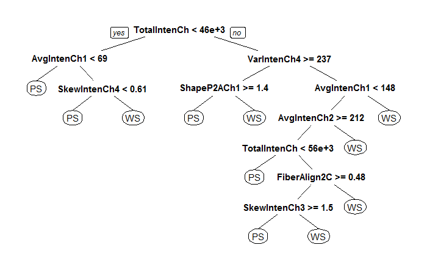

```r
prp(segBaixa_train_cart_fit)
```

Vamos agora verificar a qualidade da previsão interna (“in-sample”)

```r
segBaixa_train_cart_pred = predict(segBaixa_train_cart_fit, type="class")
length(segBaixa_train$Class)
```

```
[1] 289
```

```r
conf = table(segBaixa_train$Class, segBaixa_train_cart_pred)
conf
```

```
    segBaixa_train_cart_pred
      PS  WS
  PS  87  41
  WS  15 146
```

```r
percent(confusion(conf))
```

```
[1] "80.6%"
```

Observamos que foi possível subir a porcentagem de acerto significativamente, de 57,4% para 80.6%. Com este ajuste, obtemos um acerto total de

```r
tp = 464 + 87
fp = 42 + 41
fn = 44 + 15
tn = 170 + 146
total = 551+83+59+316
percent((tp+tn) / total)
```

```
[1] "85.9%"
```

Nesta seção vamos utilizar um modelo alternativo, randomForest, para verificar se é possível melhorar ainda mais a taxa de acerto para elementos de baixa propabilidade de acerto do modelo linear.

```r
# fazer modelo randomForest
segBaixa_train_rf_fit = randomForest(Class ~ ., data = segBaixa_train, ntree = 200, nodesize = 30)
# fazer as previsões
segBaixa_train_rf_pred = predict(segBaixa_train_rf_fit)
# verificar a confusion matrix
conf = table(segBaixa_train$Class, segBaixa_train_rf_pred)
conf
```

```
    segBaixa_train_rf_pred
      PS  WS
  PS  63  65
  WS  38 123
```

```r
percent(confusion(conf))
```

```
[1] "64.4%"
```

As previsões feitas com o randomForest são significativamente inferiores do que as feitas com o modelo CART.

## Tentando utilizar cross-validation para melhorar o resultado de CART

```r
library(e1071)
```

```r
fitControl = trainControl(method="cv", number=10)
cartGrid = expand.grid(.cp=(1:50)*0.01)
segBaixa_train_cv = train(Class ~ ., data = segBaixa_train, method = "rpart", trControl = fitControl, tuneGrid = cartGrid)
segBaixa_train_cv
```

```
CART

289 samples
 58 predictor
  2 classes: 'PS', 'WS'

No pre-processing
Resampling: Cross-Validated (10 fold)
Summary of sample sizes: 260, 260, 261, 260, 260, 261, ...
Resampling results across tuning parameters:

  cp    Accuracy   Kappa
  0.01  0.6293596  0.24083442
  0.02  0.6362562  0.25852574
  0.03  0.6433826  0.27330399
  0.04  0.6814368  0.34078506
  0.05  0.6638259  0.30178125
  0.06  0.6638259  0.30178125
  0.07  0.6671593  0.30535338
  0.08  0.6671593  0.30535338
  0.09  0.6568144  0.28166515
  0.10  0.6499179  0.26538620
  0.11  0.6395731  0.24057379
  0.12  0.6428982  0.23577194
  0.13  0.6428982  0.23577194
  0.14  0.6500411  0.24710455
  0.15  0.6500411  0.24710455
  0.16  0.6500411  0.24710455
  0.17  0.6500411  0.24710455
  0.18  0.6500411  0.24710455
  0.19  0.6500411  0.24710455
  0.20  0.6500411  0.24710455
  0.21  0.6500411  0.24710455
  0.22  0.6500411  0.24710455
  0.23  0.6500411  0.24710455
  0.24  0.6259031  0.19082314
  0.25  0.6223317  0.17501441
  0.26  0.6050903  0.13330587
  0.27  0.5709524  0.04302781
  0.28  0.5640558  0.02378730
```

[output cut: 10 more lines]

```
  0.39  0.5571593  0.00000000
  0.40  0.5571593  0.00000000
  0.41  0.5571593  0.00000000
  0.42  0.5571593  0.00000000
  0.43  0.5571593  0.00000000
  0.44  0.5571593  0.00000000
  0.45  0.5571593  0.00000000
  0.46  0.5571593  0.00000000
  0.47  0.5571593  0.00000000
  0.48  0.5571593  0.00000000
  0.49  0.5571593  0.00000000
  0.50  0.5571593  0.00000000

Accuracy was used to select the optimal model using  the largest value.
The final value used for the model was cp = 0.04.
```

```r
segBaixa_train_cv_cart_fit = rpart(Class ~ ., data = segBaixa_train, method = "class", control=rpart.control(cp = 0.09))
segBaixa_train_cv_cart_pred = predict(segBaixa_train_cv_cart_fit, type = "class")
summary(segBaixa_train_cv_cart_fit)
```

```
Call:
rpart(formula = Class ~ ., data = segBaixa_train, method = "class",
    control = rpart.control(cp = 0.09))
  n= 289

         CP nsplit rel error    xerror       xstd
1 0.2656250      0 1.0000000 1.0000000 0.06597191
2 0.1015625      1 0.7343750 0.8046875 0.06360865
3 0.0900000      2 0.6328125 0.8281250 0.06400584

Variable importance
          TotalIntenCh2             VarIntenCh4     DiffIntenDensityCh4             AvgIntenCh4
                     29                      22                      16                      14
          TotalIntenCh4             AvgIntenCh2  ConvexHullAreaRatioCh1 ConvexHullPerimRatioCh1
                     11                       6                       1                       1

Node number 1: 289 observations,    complexity param=0.265625
  predicted class=WS  expected loss=0.4429066  P(node) =1
    class counts:   128   161
   probabilities: 0.443 0.557
  left son=2 (68 obs) right son=3 (221 obs)
  Primary splits:
      TotalIntenCh2   < 45939.5    to the left,  improve=16.772030, (0 missing)
      AvgIntenCh1     < 148.0461   to the left,  improve= 8.757256, (0 missing)
      AvgIntenCh2     < 115.2054   to the left,  improve= 8.537152, (0 missing)
      TotalIntenCh1   < 26253      to the left,  improve= 7.549478, (0 missing)
      IntenCoocMaxCh3 < 0.04950333 to the right, improve= 7.208644, (0 missing)
  Surrogate splits:
      TotalIntenCh4       < 13027      to the left,  agree=0.817, adj=0.221, (0 split)
      AvgIntenCh2         < 99.79699   to the left,  agree=0.813, adj=0.206, (0 split)
      AvgIntenCh4         < 41.76886   to the left,  agree=0.813, adj=0.206, (0 split)
      DiffIntenDensityCh4 < 34.22503   to the left,  agree=0.810, adj=0.191, (0 split)
      VarIntenCh4         < 41.27028   to the left,  agree=0.806, adj=0.176, (0 split)

Node number 2: 68 observations
  predicted class=PS  expected loss=0.25  P(node) =0.2352941
    class counts:    51    17
   probabilities: 0.750 0.250

Node number 3: 221 observations,    complexity param=0.1015625
```

[output cut: 11 more lines]

```
      DiffIntenDensityCh4     < 210.7329   to the right, agree=0.928, adj=0.610, (0 split)
      AvgIntenCh4             < 299.0926   to the right, agree=0.910, adj=0.512, (0 split)
      TotalIntenCh4           < 82442.5    to the right, agree=0.864, adj=0.268, (0 split)
      ConvexHullAreaRatioCh1  < 1.018182   to the left,  agree=0.828, adj=0.073, (0 split)
      ConvexHullPerimRatioCh1 < 0.9758369  to the right, agree=0.828, adj=0.073, (0 split)

Node number 6: 41 observations
  predicted class=PS  expected loss=0.3414634  P(node) =0.1418685
    class counts:    27    14
   probabilities: 0.659 0.341

Node number 7: 180 observations
  predicted class=WS  expected loss=0.2777778  P(node) =0.6228374
    class counts:    50   130
   probabilities: 0.278 0.722
```

```r
# verificar a confusion matrix
conf = table(segBaixa_train$Class, segBaixa_train_cv_cart_pred)
conf
```

```
    segBaixa_train_cv_cart_pred
      PS  WS
  PS  78  50
  WS  31 130
```

```r
percent(confusion(conf))
```

```
[1] "72%"
```

A solução de CART com cross validation, no entanto, é superior à solução de randomForest. Sendo assim devemos utilizar CART com cross validation para os dados de teste. Vamos a seguir verificar os resultados com os dados de teste

# Utilizando os modelos nos dados de teste

```r
# obter os dados de teste apenas da região de baixa probabilidade
# definir a variável erro_test (erro potencial) como os elementos cujo erro está dentro do range em torno
# de 50%
erro_test = seg_test_glm_pred > (0.5 - range) & seg_test_glm_pred < (0.5 + range)
```

```r
bp = subset(seg_test13, erro_test == TRUE)
or = subset(seg_test13_glm_pred > 0.5, erro_test == TRUE)
conf = table(bp$Class, or)
conf
```

```
    or
     FALSE TRUE
  PS    83   53
  WS    52   91
```

```r
percent(confusion(conf))
```

```
[1] "62.4%"
```

```r
baixaProb_test = subset(seg_test, erro_test == TRUE)
baixaProb_test$Class = subset(class_test, erro_test == TRUE)
length(baixaProb_test$Class)
```

```
[1] 279
```

```r
altaProb_test = subset(seg_test, erro_test == FALSE)
altaProb_test$Class = subset(class_test, erro_test == FALSE)
length(altaProb_test$Class)
```

```
[1] 730
```

```r
baixaProb_test_cart_pred = predict(segBaixa_train_cart_fit, newdata=baixaProb_test, type = "class")
# baixaProb_test_cart_pred
# verificar a confusion matrix
conf = table(baixaProb_test$Class, baixaProb_test_cart_pred)
conf
```

```
    baixaProb_test_cart_pred
      PS  WS
  PS  59  77
  WS  30 113
```

```r
percent(confusion(conf))
```

```
[1] "61.6%"
```

```r
baixaProb_test_cv_cart_pred = predict(segBaixa_train_cv_cart_fit, newdata=baixaProb_test, type = "class")
# baixaProb_test_cart_pred
# verificar a confusion matrix
conf = table(baixaProb_test$Class, baixaProb_test_cv_cart_pred)
conf
```

```
    baixaProb_test_cv_cart_pred
      PS  WS
  PS  62  74
  WS  35 108
```

```r
percent(confusion(conf))
```

```
[1] "60.9%"
```